# Predicting Max Attack for Arknights Operators

Chuyu Zhuang

2024-09-15

# Introduction

# 1. Introduction

This is a model that predicts the maximum attack power of arknights operators.

## What is Arknights?

“Arknights” is a strategy tower defense mobile game developed by Hypergryph Network, and it is also the first game developed by Hypergryph Network.You can think of it as a anime version of Plants vs. Zombies, except that the plants here are employees working in your company, and the one who tells you to work is not Crazy Dave but a green old lynx who likes to tell riddles.

[figure not shown]

old lynx

## Why?

Like many gacha games, Arknights regularly releases new characters (referred to as operators in the game). In the past, players mostly decided whether to pull for a character based on the quality of their artwork or their portrayal in the storyline. However, as the game has continued to update and increase in difficulty, players have gradually started to decide whether to pull for new operators based on their strength.

# 2. Exploratory Data Analysis

First, we will load all of our packages and the raw data, followed by performing exploratory analysis to understand the relationships between key variables and the response variable, **max attack**.

```r
# Load necessary libraries
library(ggplot2)
library(readr)
library(dplyr)
library(car)
library(MASS)
library(caret)
library(e1071)
library(xgboost)
library(rsample)
```

```r
# Load the dataset
data <- read_csv("data.csv")
# Display first few rows of the dataset
head(data)
```

```
## # A tibble: 6 × 63
##   name        class branch faction stars position tags  trait availability icon
##   <chr>       <chr> <chr>  <chr>   <chr> <chr>    <chr> <chr> <chr>        <chr>
## 1 "Castle-3"  Guard Dread… Rhodes… 1-st… Melee    ['Su… Bloc… Recruitment  http…
## 2 "\"Justice… Snip… Marks… Pinus … 1-st… Ranged   ['Su… Atta… Recruitment  http…
## 3 "Lancet-2"  Medic Medic  Rhodes… 1-st… Ranged   ['He… Rest… Recruitment… http…
## 4 "THRM-EX"   Spec… Execu… Rhodes… 1-st… Melee    ['Nu… Does… Recruitment… http…
## 5 "12F"       Cast… Splash Rhodes… 2-st… Ranged   ['St… Deal… Recruitment… http…
## 6 "Durin"     Cast… Core   Rhodes… 2-st… Ranged   ['St… Deal… Recruitment… http…
## # ℹ 53 more variables: description <chr>, phrase <chr>, file_no. <chr>,
## #   gender <chr>, height <chr>, mobility <chr>, endurance <chr>,
## #   internal_name <chr>, base_hp <dbl>, elite_1_hp <dbl>, elite_2_hp <chr>,
## #   max_hp <chr>, trust_hp <dbl>, base_atk <dbl>, elite_1_atk <dbl>,
## #   elite_2_atk <chr>, max_atk <chr>, trust_atk <dbl>, base_def <dbl>,
## #   elite_1_def <dbl>, elite_2_def <chr>, max_def <chr>, trust_def <dbl>,
## #   base_res <dbl>, elite_1_res <dbl>, elite_2_res <chr>, max_res <chr>, …
```

## Variable Selection

Let’s mess around with the data a little bit to see what we’re currently working with

```r
dim(data)
```

```
## [1] 235  63
```

We can see that the entire data has 235 rows and 63 columns, which means there are 235 operators and 63 columns of variables. However, from the data, variables such as faction, tags, trait, availability, icon, description, phrase, file_no and other game-related variables are insignificant to the analysis of the maximum attack power of operators (after all, in this game, even if you only hold a water gun in the plot, you can become a super powerful operator in terms of strength).So we can ignore these irrelevant variables.

Some people may notice that there is a variable called branch after class. This is a category created by the game to subdivide different operators in the same class. Let’s see how many branches there are in total.

```r
distinct_count <- data %>%
  summarise(n_distinct = n_distinct(branch))

print(distinct_count)
```

```
## # A tibble: 1 × 1
##   n_distinct
##        <int>
## 1         52
```

Similarly, since our goal is to focus on the maximum attack power of the operator, something like base_hp,elite_1_hp,elite_2_hp,max_hp,trust_hp,base_atk,elite_1_atk,elite_2_atk,trust_atk,base_def,elite_1_def,elite_2_def,max_def,trust_def,base_res,elite_1_res,elite_2_res,max_res,base_redeploy,elite_1_redeploy,elite_2_redeploy,max_redeploy,base_dp_cost,e lite_1_dp_cost,elite_2_dp_cost,max_dp_cost,base_block,elite_1_block,elite_2_block,max_block,base_interval,elite_1_interval,elite_2_interval,max_interval,images,experience,place_of_birth,date_of_birth,race,infection_status,strength,tactical_acumen,combat_skill,arts_ada ptability variables can be omitted

Now, let’s filter out all those unwanted variables and our dataset will be ready for further tidying

```r
data <- data %>%
  dplyr::select("name","class", "stars", "position", "max_atk")
```

### Missing data review and cleaning

Next, let’s see if there is any missing data.

```r
# View non-numeric max_atk data
non_numeric_values <- data[is.na(as.numeric(as.character(data$max_atk))), ]

# Print rows with non-numeric max_atk (process as needed)
print(non_numeric_values)
```

```
## # A tibble: 26 × 5
##    name                 class      stars  position max_atk
##    <chr>                <chr>      <chr>  <chr>    <chr>
##  1 "Castle-3"           Guard      1-star Melee    –
##  2 "\"Justice Knight\"" Sniper     1-star Ranged   –
##  3 "Lancet-2"           Medic      1-star Ranged   –
##  4 "THRM-EX"            Specialist 1-star Melee    –
##  5 "12F"                Caster     2-star Ranged   –
##  6 "Durin"              Caster     2-star Ranged   –
##  7 "Noir Corne"         Defender   2-star Melee    –
##  8 "Rangers"            Sniper     2-star Ranged   –
##  9 "Yato"               Vanguard   2-star Melee    –
## 10 "Adnachiel"          Sniper     3-star Ranged   –
## # ℹ 16 more rows
```

```r
# Force max_atk to numeric and process NAs
data$max_atk <- as.numeric(as.character(data$max_atk))

# Remove rows with NA values
data_clean <- data[!is.na(data$max_atk), ]

print(data_clean)
```

```
## # A tibble: 209 × 5
##    name       class    stars  position max_atk
##    <chr>      <chr>    <chr>  <chr>      <dbl>
##  1 Aciddrop   Sniper   4-star Ranged       735
##  2 Ambriel    Sniper   4-star Ranged       977
##  3 Arene      Guard    4-star Melee        640
##  4 Beanstalk  Vanguard 4-star Ranged       405
##  5 Beehunter  Guard    4-star Melee        513
##  6 Bubble     Defender 4-star Melee        370
##  7 Chestnut   Medic    4-star Ranged       389
##  8 Click      Caster   4-star Ranged       315
##  9 Conviction Guard    4-star Melee        929
## 10 Courier    Vanguard 4-star Melee        435
## # ℹ 199 more rows
```

### Univariate Analysis: Distribution of Max Attack

First, let’s look at the distribution of maximum attack power.

[figure not shown]

```r
# Plotting the distribution of max attack
ggplot(data_clean, aes(x = max_atk)) +
  geom_histogram(binwidth = 50, fill = "blue", color = "white") +
  labs(title = "Distribution of Base Attack", x = "Base Attack", y = "Count")
```

#### What can we find?

- The distribution of max attack shows that the maximum attack power of 550 operators is the most, with fewer operators having extremely high or low values.

### Bivariate Analysis: Relationship Between Predictors and Max Attack

Next, let’s look at the relationship between the star and position and the maximum attack power.

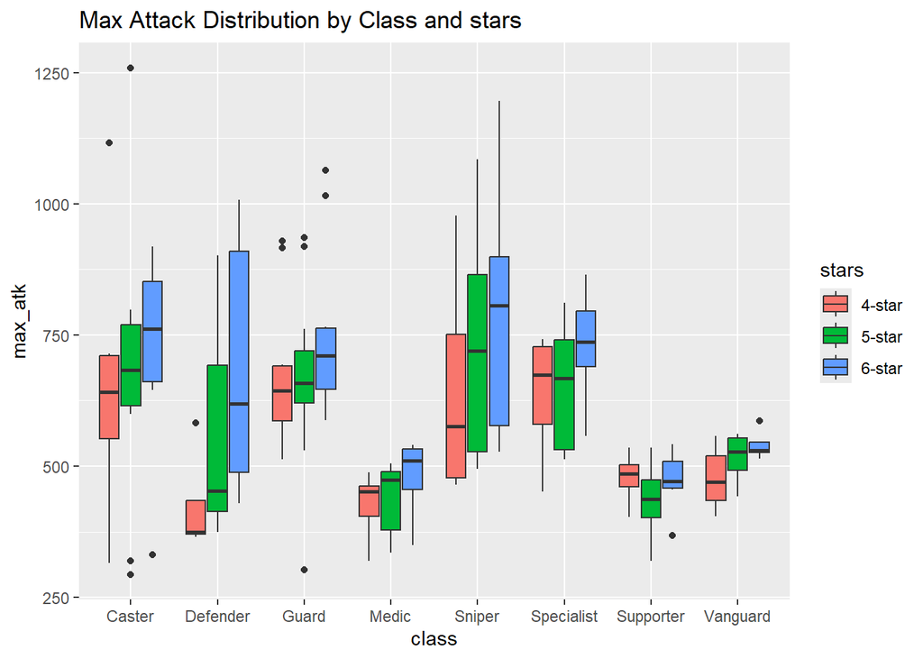

```r
# Plotting relationships between class, stars, and max attack
ggplot(data_clean, aes(x = class, y = max_atk, fill = stars)) +
  geom_boxplot() +
  ggtitle("Max Attack Distribution by Class and stars")
```

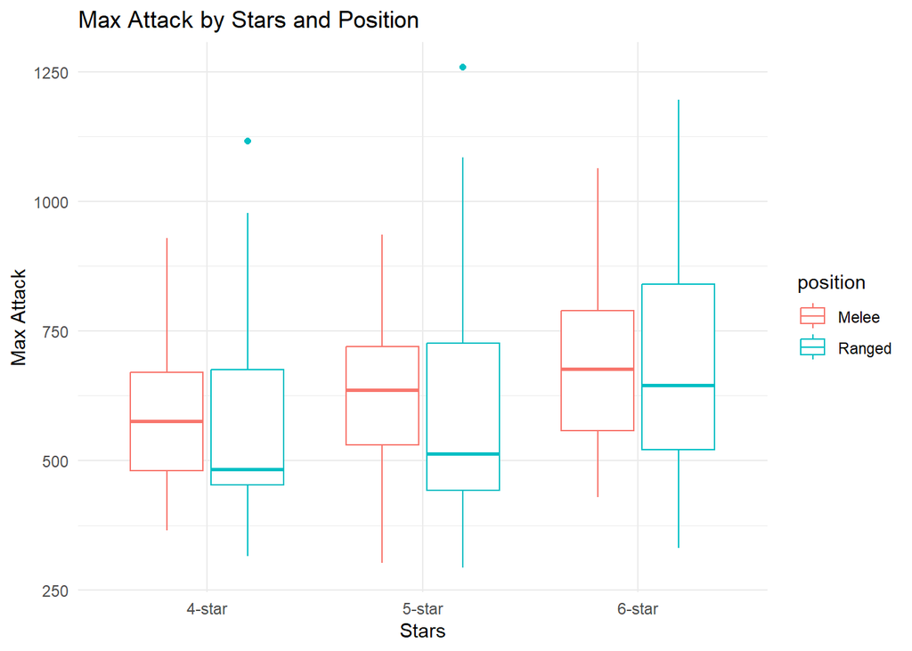

```r
# Plotting relationships between class, positions, and max attack
ggplot(data_clean, aes(x = stars, y = max_atk, color = position)) +
  geom_boxplot() +
  labs(title = "Max Attack by Stars and Position", x = "Stars", y = "Max Attack") +
  theme_minimal()
```

#### What can we find?

- Operators with higher stars and certain classes tend to have higher max attack values, as shown by the spread in the box plots.
- Regardless of the star level, the maximum value of the ranged attack power is higher than the maximum value of the melee, but the minimum value is lower than the minimum value of the melee.

# 3. Data Splitting and Cross Validation

The first step we must take before fitting any model is to split our data into a training set and a test set. The training set will be used to do just that: train our model. The test set acts as a test because our model will not be trained using this data. Therefore, once we fit what we consider to be the “best” model (usually based on the lowest RMSE, or Root Mean Squared Error of regression) to our test set, we will see how it truly performs on new data. By splitting our data into a test set and a training set, we can avoid overfitting because the model is not learning using all of the available data. The split that I chose is a 70/30 split, meaning that 70% of the data will go into the training set and 30% of the data will go into the test set. This way, the majority of our data is used to train the model; however, we still have enough data to test the model. Additionally, the split is stratified based on the outcome variable, max_atk, to ensure that the max_atk distributions for the training and test data are equal.

```r
# Data Splitting
set.seed(123)
data_split <- initial_split(data_clean, prop = 0.7, strata = max_atk)
train <- training(data_split)
test <- testing(data_split)

# Define cross validation controls
ctrl <- trainControl(method = "cv", number = 10)
```

check the data split correct

```r
nrow(train)/nrow(data_clean)
```

```
## [1] 0.6937799
```

```r
nrow(test)/nrow(train)
```

```
## [1] 0.4413793
```

The training set has about 70% of the data and the testing set has about 30% of the data. So, the data was split correctly between the training and testing sets.

# 4. Model Fitting and Results

We will now build several machine learning models to predict the **max attack** of new operators.

### Model 1: linear regression model

```r
# Fit a linear regression model using class, stars, and Initial deployment cost as predictors
model_lm <- train(max_atk ~ class + stars + position,
                  data = train,
                  method = "lm",
                  trControl = ctrl)

# Summary of the linear model
summary(model_lm$finalModel)
```

```
##
## Call:
## lm(formula = .outcome ~ ., data = dat)
##
## Residuals:
##     Min      1Q  Median      3Q     Max
## -402.60  -86.11   -8.76   63.95  491.68
##
## Coefficients:
##                 Estimate Std. Error t value Pr(>|t|)
## (Intercept)       746.97      87.38   8.549 2.47e-14 ***
## classDefender    -190.42      95.18  -2.001  0.04746 *
## classGuard        -89.05      91.24  -0.976  0.33079
## classMedic       -235.76      53.54  -4.404 2.16e-05 ***
## classSniper        12.39      46.74   0.265  0.79130
## classSpecialist  -130.25      89.89  -1.449  0.14967
## classSupporter   -246.94      50.27  -4.912 2.58e-06 ***
## classVanguard    -261.06      90.62  -2.881  0.00462 **
## `stars5-star`      43.74      31.92   1.370  0.17290
## `stars6-star`     109.28      35.89   3.045  0.00280 **
## positionRanged   -122.65      79.94  -1.534  0.12734
## ---
## Signif. codes:  0 '***' 0.001 '**' 0.01 '*' 0.05 '.' 0.1 ' ' 1
##
## Residual standard error: 151.4 on 134 degrees of freedom
## Multiple R-squared:  0.3625, Adjusted R-squared:  0.3149
## F-statistic: 7.619 on 10 and 134 DF,  p-value: 1.484e-09
```

### Model 2: Lasso regression

```r
# Train Lasso regression model with the adjusted predictors
model_lasso <- train(max_atk ~ class + stars + position,
                     data = train,
                     method = "glmnet",
                     trControl = ctrl,
                     tuneLength = 5)

# Print Lasso model summary
print(model_lasso)
```

```
## glmnet
##
## 145 samples
##   3 predictor
##
## No pre-processing
## Resampling: Cross-Validated (10 fold)
## Summary of sample sizes: 129, 131, 130, 130, 132, 132, ...
## Resampling results across tuning parameters:
##
##   alpha  lambda       RMSE      Rsquared   MAE
##   0.100   0.05669914  149.7943  0.3504850  115.0645
##   0.100   0.26317410  149.7600  0.3505127  115.0319
##   0.100   1.22154598  149.6407  0.3495121  115.0451
##   0.100   5.66991419  149.6303  0.3450433  115.4381
##   0.100  26.31741040  150.3043  0.3382401  115.8907
##   0.325   0.05669914  149.7914  0.3505947  115.0689
##   0.325   0.26317410  149.7342  0.3504401  115.0062
##   0.325   1.22154598  149.6426  0.3483420  115.1778
##   0.325   5.66991419  150.0261  0.3385029  116.0554
##   0.325  26.31741040  150.5969  0.3402859  116.0283
##   0.550   0.05669914  149.7886  0.3505542  115.0665
##   0.550   0.26317410  149.7112  0.3503475  114.9856
##   0.550   1.22154598  149.6931  0.3466456  115.4270
##   0.550   5.66991419  149.8371  0.3385849  115.8370
##   0.550  26.31741040  151.6822  0.3423615  116.5939
##   0.775   0.05669914  149.7888  0.3505896  115.0679
##   0.775   0.26317410  149.6910  0.3502323  114.9849
##   0.775   1.22154598  149.6659  0.3457411  115.6037
##   0.775   5.66991419  149.6352  0.3399255  115.6232
##   0.775  26.31741040  154.2923  0.3333257  119.3771
##   1.000   0.05669914  149.7809  0.3506140  115.0599
##   1.000   0.26317410  149.6749  0.3500780  115.0087
##   1.000   1.22154598  149.5358  0.3463678  115.5118
##   1.000   5.66991419  149.5242  0.3411336  115.4730
##   1.000  26.31741040  157.8825  0.3155988  124.0377
##
## RMSE was used to select the optimal model using the smallest value.
## The final values used for the model were alpha = 1 and lambda = 5.669914.
```

### Model 3: Random forest model

```r
# Train Lasso regression model with the adjusted predictors
model_rf <- train(max_atk ~ class + stars + position,
                  data = train,
                  method = "rf",
                  trControl = ctrl,
                  tuneLength = 5)


# Print Lasso model summary
print(model_lasso)
```

[output not shown]

## Model 4: Support vector machine(SVM)

```r
# # Train SVM model with the adjusted predictors
model_svm <- train(max_atk ~ class + stars + position,
                   data = train,
                   method = "svmLinear",
                   trControl = ctrl,
                   tuneLength = 5)

summary(model_svm$finalModel)
```

```
## Length  Class   Mode
##      1   ksvm     S4
```

# 5. Model Selection

We compare the performance of the models based on RMSE, and select the best-performing model.

```r
# Predict on test set
pred_lm <- predict(model_lm, newdata = test)
pred_lasso <- predict(model_lasso, newdata = test)
pred_rf <- predict(model_rf, newdata = test)
pred_svm <- predict(model_svm, newdata = test)

# Calculate RMSE for each model
rmse_lm <- sqrt(mean((test$max_atk - pred_lm)^2))
rmse_lasso <- sqrt(mean((test$max_atk - pred_lasso)^2))
rmse_rf <- sqrt(mean((test$max_atk - pred_rf)^2))
rmse_svm <- sqrt(mean((test$max_atk - pred_svm)^2))

# Print RMSE results
print(paste("Linear Regression RMSE:", rmse_lm))
```

```
## [1] "Linear Regression RMSE: 165.035647868777"
```

```r
print(paste("Lasso Regression RMSE:", rmse_lasso))
```

```
## [1] "Lasso Regression RMSE: 168.767820416791"
```

```r
print(paste("Random Forest RMSE:", rmse_rf))
```

```
## [1] "Random Forest RMSE: 166.862616730871"
```

```r
print(paste("SVM RMSE:", rmse_svm))
```

```
## [1] "SVM RMSE: 161.055589331847"
```

## 6. Testing Model

Now let’s look at how the better performing linear model and the best performing SVM model perform on untrained data.

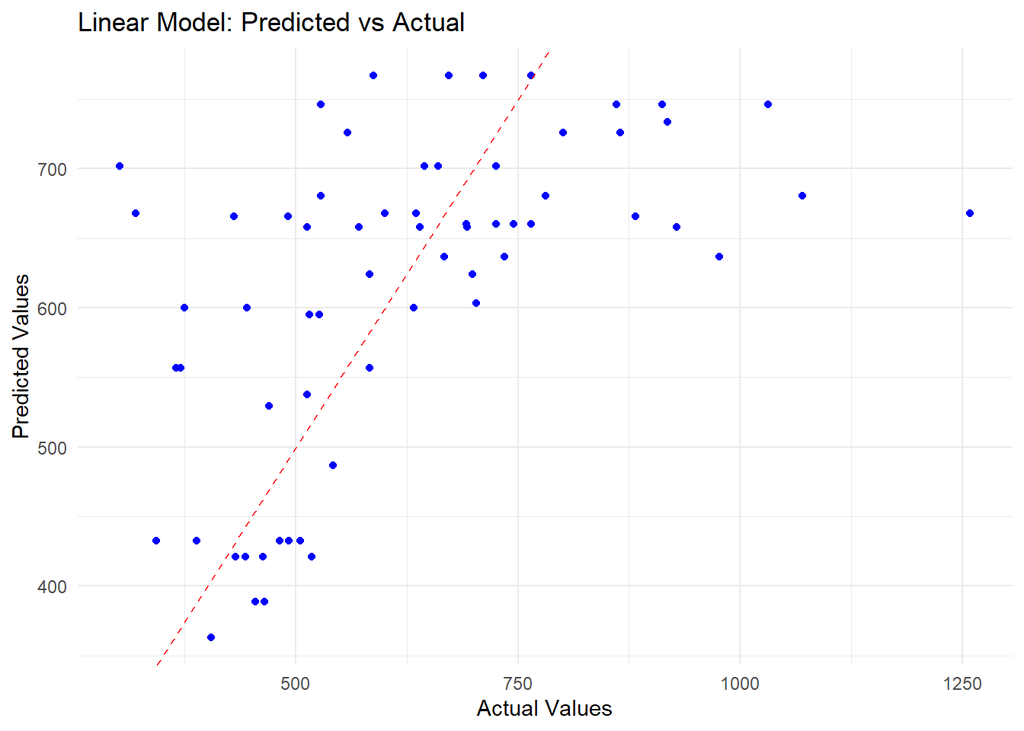

```r
# Generate predictions using the linear model
pred_lm <- predict(model_lm, newdata = test)

# Combine actual and predicted values
results_lm <- data.frame(Actual = test$max_atk, Predicted = pred_lm)

# Plot 1: Predicted vs Actual
ggplot(results_lm, aes(x = Actual, y = Predicted)) +
  geom_point(color = "blue") +
  geom_abline(slope = 1, intercept = 0, linetype = "dashed", color = "red") +
  labs(title = "Linear Model: Predicted vs Actual", x = "Actual Values", y = "Predicted Values") +
  theme_minimal()
```

Many points fall below the red line, which indicates that the linear model underestimates the values when the actual values are higher. There are also some clear divergences, which means that the model’s predictions are off from the actual values, especially at higher levels (around 750+).

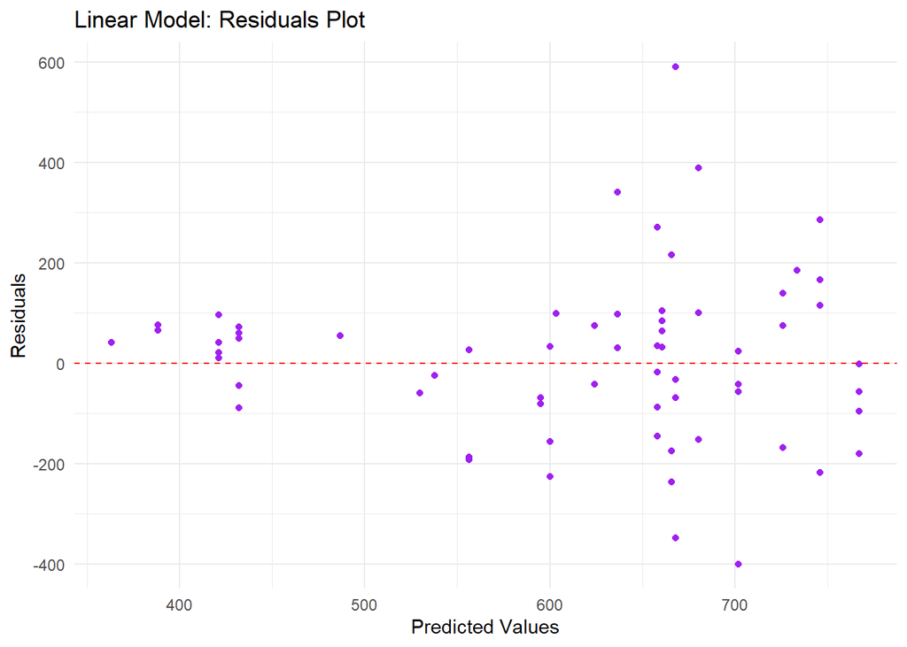

```r
# Plot 2: Residuals Plot
results_lm$Residuals <- results_lm$Actual - results_lm$Predicted
ggplot(results_lm, aes(x = Predicted, y = Residuals)) +
  geom_point(color = "purple") +
  geom_hline(yintercept = 0, linetype = "dashed", color = "red") +
  labs(title = "Linear Model: Residuals Plot", x = "Predicted Values", y = "Residuals") +
  theme_minimal()
```

The residual plot shows the difference between the predicted values and the actual values (residuals) over a range of predicted values. Ideally, the residuals should be randomly distributed around zero with no obvious pattern, indicating a good model fit. In our model, however, the residuals appear relatively random, but with larger residuals for predictions between 500 and 700. There is a concentration of positive residuals (underestimations) at the lower predicted values (around 400-500), with some negative residuals (overestimations) at higher predicted values (700+). This pattern suggests that the model has difficulty capturing the true values at the extremes.

### SMV Predicted vs Actual Plot

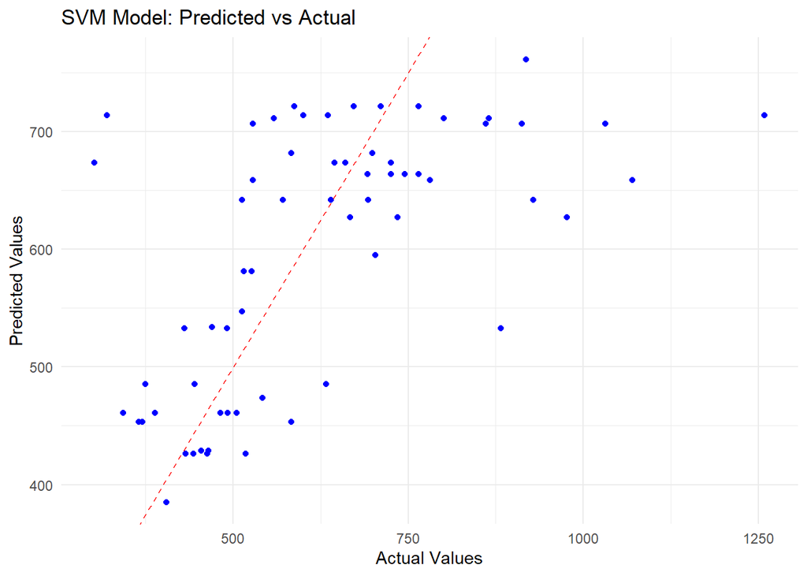

```r
# Generate predictions
pred_svm <- predict(model_svm, newdata = test)

# Combine predicted and actual values
results <- data.frame(Actual = test$max_atk, Predicted = pred_svm)
# Plot 1: Predicted vs Actual
ggplot(results, aes(x = Actual, y = Predicted)) +
  geom_point(color = "blue") +
  geom_abline(slope = 1, intercept = 0, linetype = "dashed", color = "red") +
  labs(title = "SVM Model: Predicted vs Actual", x = "Actual Values", y = "Predicted Values") +
  theme_minimal()
```

In this plot, you can see how well the SVM model’s predictions align with the actual values. The red dashed line represents the perfect prediction (i.e., predicted = actual). Ideally, the blue points should lie on this line. From the plot, there is a visible spread, indicating that the SVM model has some prediction errors but captures the trend of the data.

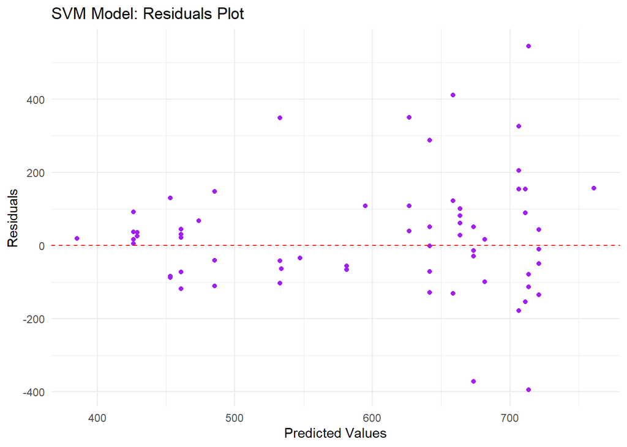

```r
# Plot 2: Residuals Plot
results$Residuals <- results$Actual - results$Predicted
ggplot(results, aes(x = Predicted, y = Residuals)) +
  geom_point(color = "purple") +
  geom_hline(yintercept = 0, linetype = "dashed", color = "red") +
  labs(title = "SVM Model: Residuals Plot", x = "Predicted Values", y = "Residuals") +
  theme_minimal()
```

The residuals plot displays the difference between the actual and predicted values. Points scattered around the red dashed line (which represents zero residuals) indicate how well the model is performing. There is some variance in the residuals, with larger deviations from zero at certain points. However, the residuals appear fairly random, which is a good sign that the model is not systematically biased.

## Conclusion

This analysis explored various machine learning models to predict the maximum attack power of Arknights operators based on features such as class, star rating, and position. The models tested included Linear Regression, Lasso Regression, Support Vector Machines (SVM), and Random Forest. Our goal was to identify the model that could most accurately predict operator performance, using Root Mean Squared Error (RMSE) as the primary evaluation metric.

### Model Comparison

Both Linear Regression and Lasso Regression yielded similar RMSE values, around 165, indicating comparable predictive power. While these linear models captured general trends, they struggled to accurately predict operators with very high attack power, leading to underestimation in those cases. Despite their simplicity, these models offer valuable insights, particularly regarding the contribution of features like star rating and class to attack power. For example, higher star ratings positively influenced attack power, while classes such as Medics and Defenders had negative impacts, aligning with their intended roles in the game.

### Insights from the Linear Model

Despite not being the most accurate model, the Linear Regression model provided important interpretive insights. The coefficient analysis highlighted the significant impact of star ratings on attack power, where higher star ratings were associated with higher attack values. In contrast, classes such as Defenders and Medics, which are typically designed for defense and healing, contributed negatively to predicted attack power. The effect of operator position was also evident, with ranged positions contributing less to attack power compared to melee roles.

However, the Predicted vs Actual and Residuals Plot for the linear model highlighted some of its weaknesses. The linear model underestimated operators with higher attack power, especially for values exceeding 700. The residuals plot further showed a pattern of non-random errors, suggesting that the linear model struggled to capture non-linear relationships in the data.

### Future Directions

Although the SVM model was the most accurate, there are still opportunities to improve predictive performance. Future enhancements could include incorporating additional features like operator skills, traits, or synergies between operators to provide a more holistic view of attack power. Additionally, more advanced machine learning techniques such as deep learning or ensemble models like Gradient Boosting Machines (GBM) could be explored to improve accuracy further.

### Final Conclusion

[figure not shown]

## Source

This data was taken from the Kaggle data set, [Arknights Operators](https://www.kaggle.com/datasets/victorsoeiro/arknights-operators/data) and it was scraped from from [Arknights Fandom Wiki](https://arknights.fandom.com/wiki/Arknights_Wiki) by user Victor Soeiro.